# Habits

# Instalando os pacotes

```r
# install.packages("base")
library(ggplot2)
# install.packages("corrplot")
library(corrplot)
# install.packages("fmsb")
library(fmsb)
# install.packages("ggplot2")
library(ggplot2)
# install.packages("dplyr")
library(dplyr)
# install.packages("rmarkdown")
library(rmarkdown)
```

# Preparar dados

```r
tc <- read.table("./data/tc.txt", header = TRUE)
ts <- read.table("./data/ts.txt", header = TRUE)

dataframe_tempos <- cbind(tc, ts)

colnames(dataframe_tempos) <- c("chegada", "servico")

dataframe_tempos$chegada <- as.numeric(dataframe_tempos$chegada)
dataframe_tempos$servico <- as.numeric(dataframe_tempos$servico)
summary(dataframe_tempos)
```

```
##     chegada          servico
##  Min.   : 0.000   Min.   : 8.00
##  1st Qu.: 3.000   1st Qu.: 9.00
##  Median : 5.000   Median :11.00
##  Mean   : 4.628   Mean   :11.02
##  3rd Qu.: 6.000   3rd Qu.:13.00
##  Max.   :10.000   Max.   :14.00
```

```r
colunas <- c(
  "valor_corte",
  "percentual_corte",
  "qtde_minimo_atendido",
  "algoritmo",
  "qtde_atendentes",
  "tempo_total",
  "tempo_total_da_fila_ocupada",
  "tempo_max_fila",
  "media_na_fila",
  "tamanho_max_fila",
  "tempo_atendente_ocioso_media"
)
```

# Modelo de Entrada

## Calculando os outliers

```r
# Outliers da chegada
quantile_chegada <- quantile(dataframe_tempos$chegada, probs = c(.25, .50, .75), na.rm = FALSE)
amplitude_chegada <- max(dataframe_tempos$chegada) - min(dataframe_tempos$chegada)

# Outliers da chegada
quantile_servico <- quantile(dataframe_tempos$servico, probs = c(.25, .50, .75), na.rm = FALSE)
amplitude_servico <- max(dataframe_tempos$servico) - min(dataframe_tempos$servico)
```

## Exploração dos dados

### Criando data frame com medidas de posição e dispersão dos dados

```r
df_medidas <- data.frame(
  Dado = c("Média", "Desvio Padrão", "Variância", "Mediana", "Mínimo", "Máximo", "Amplitude", "Q1", "Q3", "Outlier Baixo Moderado", "Outlier Alto Moderado", "Outlier Baixo Extremo", "Outlier Alto Extremo"),
  TempoChegada = c(
    mean(dataframe_tempos$chegada),  # média
    sd(dataframe_tempos$chegada),  # desvio padrão
    var(dataframe_tempos$chegada),  # variância da amostra
    median(dataframe_tempos$chegada),  # mediana
    min(dataframe_tempos$chegada),  # minimo
    max(dataframe_tempos$chegada),  # maximo
    amplitude_chegada,  # amplitude,
    quantile_chegada[1],
    quantile_chegada[3],
    quantile_chegada[1] - 1.5 * amplitude_chegada,
    quantile_chegada[3] + 1.5 * amplitude_chegada,
    quantile_chegada[1] - 3 * amplitude_chegada,
    quantile_chegada[3] + 3 * amplitude_chegada
  ),
  TempoServico = c(
    mean(dataframe_tempos$servico),  # média
    sd(dataframe_tempos$servico),  # desvio padrão
    var(dataframe_tempos$servico),  # variância da amostra
    median(dataframe_tempos$servico),  # mediana
    min(dataframe_tempos$servico),  # minimo
    max(dataframe_tempos$servico),  # maximo
    amplitude_servico,  # amplitude
    quantile_servico[1],
    quantile_servico[3],
    quantile_servico[1] - 1.5 * amplitude_servico,
    quantile_servico[3] + 1.5 * amplitude_servico,
    quantile_servico[1] - 3 * amplitude_servico,
    quantile_servico[3] + 3 * amplitude_servico
  )
)

df_medidas
```

```
##                      Dado TempoChegada TempoServico
## 1                   Média     4.628000    11.016000
## 2           Desvio Padrão     1.949569     1.987851
## 3               Variância     3.800819     3.951550
## 4                 Mediana     5.000000    11.000000
## 5                  Mínimo     0.000000     8.000000
## 6                  Máximo    10.000000    14.000000
## 7               Amplitude    10.000000     6.000000
## 8                      Q1     3.000000     9.000000
## 9                      Q3     6.000000    13.000000
## 10 Outlier Baixo Moderado   -12.000000     0.000000
## 11  Outlier Alto Moderado    21.000000    22.000000
## 12  Outlier Baixo Extremo   -27.000000    -9.000000
## 13   Outlier Alto Extremo    36.000000    31.000000
```

#### Com o dataframe é possível identificar que o dataset não possui outliers.

## Histograma

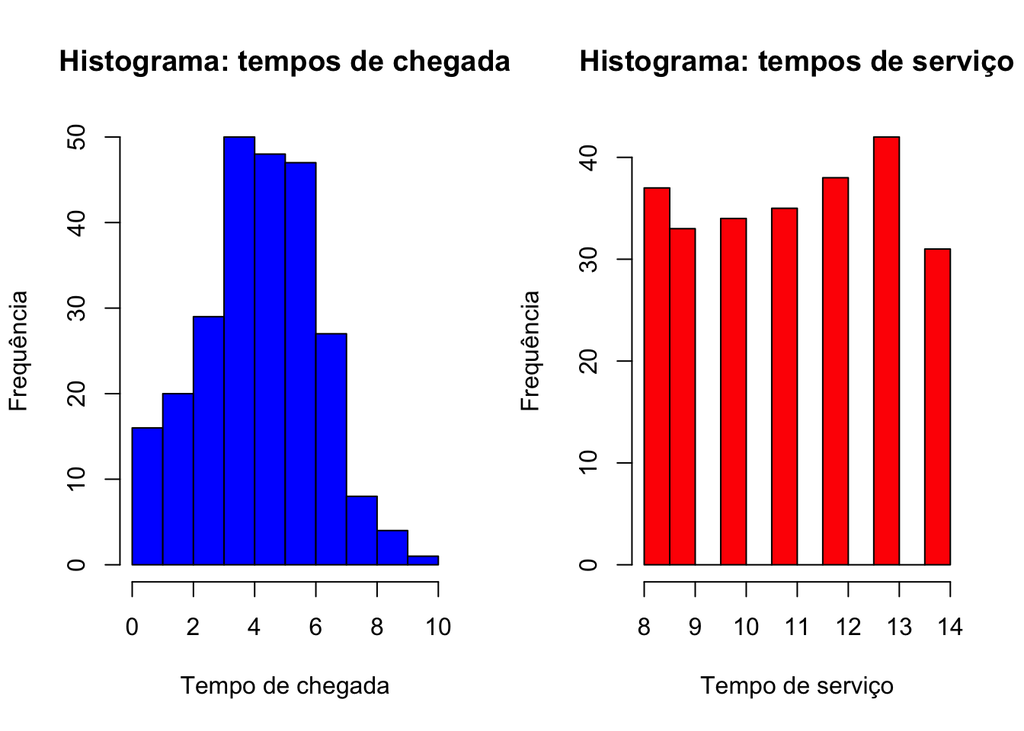

```r
par(mfrow = c(1, 2))
hist(dataframe_tempos$chegada, main = "Histograma: tempos de chegada", xlab = "Tempo de chegada", ylab = "Frequência", col = "blue")
hist(dataframe_tempos$servico, main = "Histograma: tempos de serviço", xlab = "Tempo de serviço", ylab = "Frequência", col = "red")
```

### Utilizando os histogramas gerados podemos observar que os dados de chegada seguem uma distribuição normal, já o tempo de seviço é uma distribuição uniforme

## Correlação

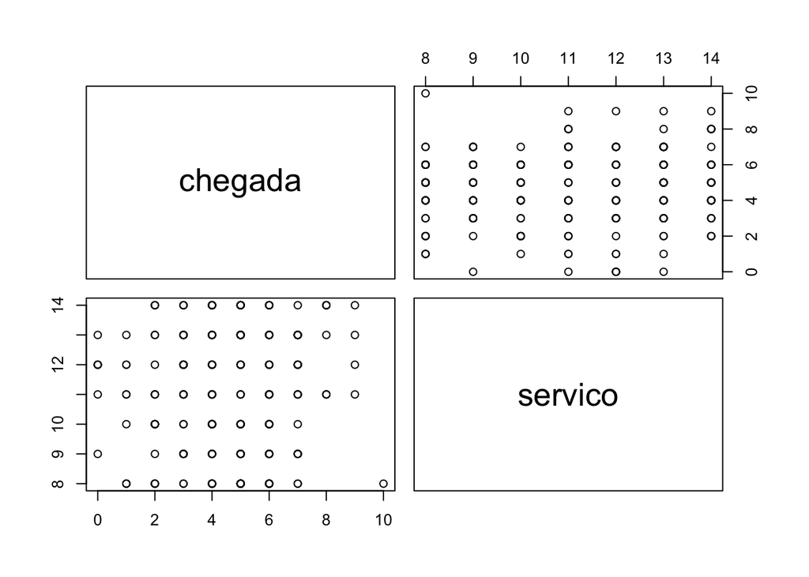

```r
pairs(dataframe_tempos)
```

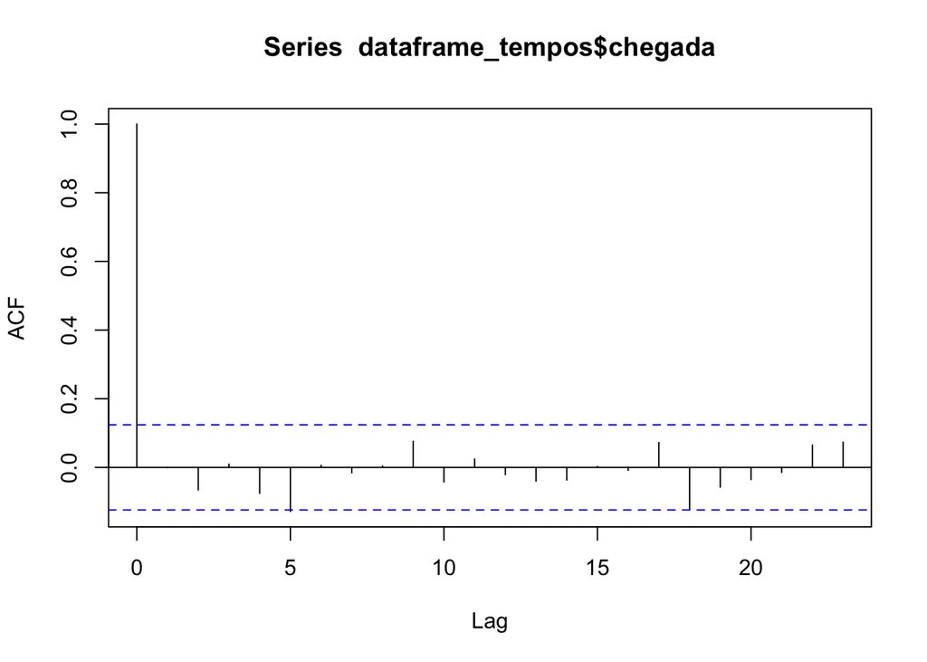

```r
acf(dataframe_tempos$chegada, pl = TRUE)
```

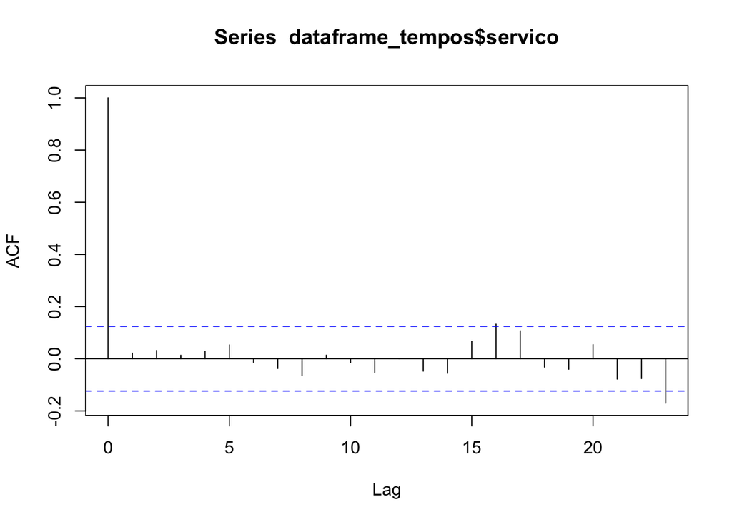

```r
acf(dataframe_tempos$servico, pl = TRUE)
```

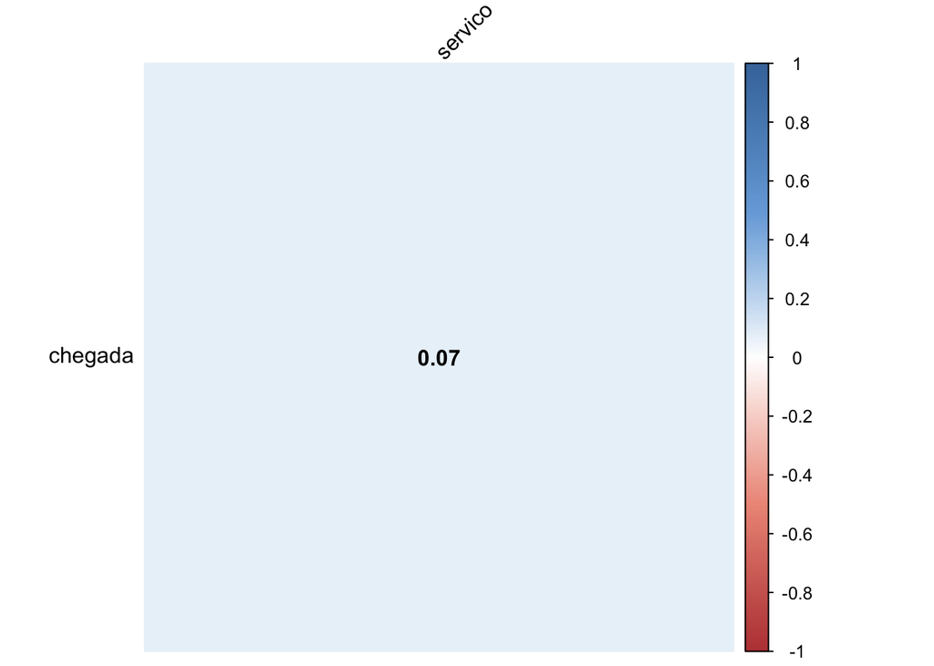

```r
col <- colorRampPalette(c("#BB4444", "#EE9988", "#FFFFFF", "#77AADD", "#4477AA"))
corrplot(cor(dataframe_tempos), method="color", col=col(200),
         type="upper",
         order="hclust",
         addCoef.col = "black", # Add coefficient of correlation
         tl.col="black", tl.srt=45, #Text label color and rotation
         diag=FALSE
)
```

# Criando funções ## Simulador Computacional quantitativo ## Variavel: Quantidade de atendentes ## Mode: Os atendimentos são atendidos por ordem de chegada

```r
simulador_computacional <- function(dados, qtde_atendentes) {
  fila <- data.frame()
  atendidos <- 0
  qtde_chegadas <- 0
  unidade_tempo <- 0
  tempo_total_da_fila_ocupada <- 0
  tempo_total_na_fila <- 0
  tamanho_max_fila <- 0
  tempo_max_fila <- 0
  tempo_atendente_ocioso <- 0
  atendentes <- data.frame(disponivel = rep(TRUE, qtde_atendentes), tempo_servico = rep(0, qtde_atendentes), tempo_atendimento = rep(0, qtde_atendentes))

  dados$soma_chegada <- cumsum(dados$chegada)

  while (atendidos < nrow(dados)) {
    while (!is.na(dados$soma_chegada[qtde_chegadas + 1]) && dados$soma_chegada[qtde_chegadas + 1] == unidade_tempo) {
      fila <- rbind(fila, dados[qtde_chegadas + 1,])
      qtde_chegadas <- qtde_chegadas + 1
    }

    if (nrow(fila) > 0) {
      tempo_total_da_fila_ocupada <- tempo_total_da_fila_ocupada + 1
      fila
    }

    if (nrow(fila) > tamanho_max_fila) {
      tamanho_max_fila <- nrow(fila)
    }

    for (i in 1:qtde_atendentes) {
      if (atendentes$disponivel[i]) {
        if (nrow(fila) > 0) {
          atendentes$tempo_servico[i] <- fila$servico[1]
          atendentes$disponivel[i] <- FALSE
          atendentes$tempo_atendimento[i] <- 0
          tempo_total_na_fila <- tempo_total_na_fila + (unidade_tempo - fila$soma_chegada[1])
          if ((unidade_tempo - fila$soma_chegada[1]) > tempo_max_fila) {
            tempo_max_fila <- unidade_tempo - fila$soma_chegada[1]
          }
          fila <- fila[-1,]
        } else {
          tempo_atendente_ocioso <- tempo_atendente_ocioso + 1
        }
      } else {
        atendentes$tempo_atendimento[i] <- atendentes$tempo_atendimento[i] + 1
        if (atendentes$tempo_atendimento[i] == atendentes$tempo_servico[i]) {
          atendidos <- atendidos + 1
          atendentes$disponivel[i] <- TRUE
          atendentes$tempo_atendimento[i] <- 0
          atendentes$tempo_servico[i] <- 0
        }
      }
    }

    unidade_tempo <- unidade_tempo + 1
  }

  return(data.frame(
    atendidos = atendidos,
    qtde_chegadas = qtde_chegadas,
    qtde_atendentes = qtde_atendentes,
    tempo_total = unidade_tempo,
    tempo_total_da_fila_ocupada = tempo_total_da_fila_ocupada,
    tempo_max_fila = tempo_max_fila,
    tempo_total_na_fila = tempo_total_na_fila,
    media_na_fila = tempo_total_na_fila / qtde_chegadas,
    tamanho_max_fila = tamanho_max_fila,
    tempo_atendente_ocioso = tempo_atendente_ocioso,
    tempo_atendente_ocioso_media = tempo_atendente_ocioso / qtde_atendentes,
    algoritmo = NA,
    valor_corte = NA,
    percentual_corte = NA,
    qtde_minimo_atendido = NA,
    metodo = NA
  ))
}
```

## Simulador Computacional por prioridade

## Variavel: Quantidade de atendentes

## Mode: Os atendimentos são atendidos por ordem de chegada e prioridade, para cada QTDE_MINIMO_ATENDIDO chamados com tempo de serviço MENOR OU IGUAL ao VALOR_CORTE, um chamado com tempo de serviço MAIOR que VALOR_CORTE é atendido. Caso não tenha serviços na fila adequados, o primeiro da fila sera atendido.

```r
simulador_computacional_prioridade_corte <- function(dados, qtde_atendentes, valor_corte, qtde_minimo_atendido = 2) {
  fila <- data.frame()
  atendidos <- 0
  qtde_chegadas <- 0
  unidade_tempo <- 0
  tempo_total_da_fila_ocupada <- 0
  tempo_total_na_fila <- 0
  tamanho_max_fila <- 0
  tempo_max_fila <- 0
  tempo_atendente_ocioso <- 0
  chamados_atendidos_corte <- 0
  atendentes <- data.frame(disponivel = rep(TRUE, qtde_atendentes), tempo_servico = rep(0, qtde_atendentes), tempo_atendimento = rep(0, qtde_atendentes))

  dados$soma_chegada <- cumsum(dados$chegada)

  while (atendidos < nrow(dados)) {
    while (!is.na(dados$soma_chegada[qtde_chegadas + 1]) && dados$soma_chegada[qtde_chegadas + 1] == unidade_tempo) {
      fila <- rbind(fila, dados[qtde_chegadas + 1,])
      qtde_chegadas <- qtde_chegadas + 1
    }

    if (nrow(fila) > 0) {
      tempo_total_da_fila_ocupada <- tempo_total_da_fila_ocupada + 1
      fila
    }

    if (nrow(fila) > tamanho_max_fila) {
      tamanho_max_fila <- nrow(fila)
    }

    for (i in 1:qtde_atendentes) {
      if (atendentes$disponivel[i]) {
        if (nrow(fila) > 0) {
          indice <- 1
          if (chamados_atendidos_corte < qtde_minimo_atendido) {
            for (j in seq_len(nrow(fila))) {
              if (fila$servico[j] <= valor_corte) {
                indice <- j
                chamados_atendidos_corte <- chamados_atendidos_corte + 1
                break
              }
            }
          } else {
            for (j in seq_len(nrow(fila))) {
              if (fila$servico[j] >= valor_corte) {
                indice <- j
                chamados_atendidos_corte <- 0
                break
              }
            }
          }

          atendentes$tempo_servico[i] <- fila$servico[indice]
          atendentes$tempo_servico[i] <- fila$servico[indice]
          atendentes$disponivel[i] <- FALSE
          atendentes$tempo_atendimento[i] <- 0
          tempo_total_na_fila <- tempo_total_na_fila + (unidade_tempo - fila$soma_chegada[indice])
          if ((unidade_tempo - fila$soma_chegada[indice]) > tempo_max_fila) {
            tempo_max_fila <- unidade_tempo - fila$soma_chegada[indice]
          }
          fila <- fila[-indice,]
        } else {
          tempo_atendente_ocioso <- tempo_atendente_ocioso + 1
        }
      } else {
        atendentes$tempo_atendimento[i] <- atendentes$tempo_atendimento[i] + 1
        if (atendentes$tempo_atendimento[i] == atendentes$tempo_servico[i]) {
          atendidos <- atendidos + 1
          atendentes$disponivel[i] <- TRUE
          atendentes$tempo_atendimento[i] <- 0
          atendentes$tempo_servico[i] <- 0
        }
      }
    }

    unidade_tempo <- unidade_tempo + 1
  }

  return(data.frame(
    atendidos = atendidos,
    qtde_chegadas = qtde_chegadas,
    qtde_atendentes = qtde_atendentes,
    tempo_total = unidade_tempo,
    tempo_total_da_fila_ocupada = tempo_total_da_fila_ocupada,
    tempo_max_fila = tempo_max_fila,
    tempo_total_na_fila = tempo_total_na_fila,
    media_na_fila = tempo_total_na_fila / qtde_chegadas,
    tamanho_max_fila = tamanho_max_fila,
    tempo_atendente_ocioso = tempo_atendente_ocioso,
    tempo_atendente_ocioso_media = tempo_atendente_ocioso / qtde_atendentes,
    algoritmo = NA,
    valor_corte = NA,
    percentual_corte = NA,
    qtde_minimo_atendido = NA,
    metodo = NA
  ))
}
```

## Simulador com for i

```r
simulador_computacional_iteracao <- function(qtde_atendentes, qtde_iteracao, percentual_corte = NA, qtde_minimo_atendido = 2, m = "median") {
  # Criando df com dados aleatórios e limpado-o, necessário para reutizar o método varias vezes sem
  # ter problemas com resido de dados no contexto
  df_simulados_temp <- rbind(simulador_computacional(gerar_numeros_aleatorios(nrow(dataframe_tempos)), qtde_atendentes))
  df_simulados_temp <- df_simulados_temp[0,]

  for (i in 1:qtde_iteracao) {
    if (!is.na(percentual_corte)) {
      temp <- gerar_numeros_aleatorios(nrow(dataframe_tempos))
      valor_corte <- quantile(temp$servico, probs = c(percentual_corte), na.rm = FALSE)
      df_simulados_temp <- rbind(df_simulados_temp, simulador_computacional_prioridade_corte(temp, qtde_atendentes, valor_corte, qtde_minimo_atendido))
    } else {
      df_simulados_temp <- rbind(df_simulados_temp, simulador_computacional(gerar_numeros_aleatorios(nrow(dataframe_tempos)), qtde_atendentes))
    }
  }

  if (m == "mean") {
    df_simulados_temp$metodo <- as.factor("mean")
    df_simulados_temp$atendidos <- mean(df_simulados_temp$atendidos)
    df_simulados_temp$qtde_chegadas <- mean(df_simulados_temp$qtde_chegadas)
    df_simulados_temp$qtde_atendentes <- mean(df_simulados_temp$qtde_atendentes)
    df_simulados_temp$tempo_total <- mean(df_simulados_temp$tempo_total)
    df_simulados_temp$tempo_total_da_fila_ocupada <- mean(df_simulados_temp$tempo_total_da_fila_ocupada)
    df_simulados_temp$tempo_max_fila <- mean(df_simulados_temp$tempo_max_fila)
    df_simulados_temp$tempo_total_na_fila <- mean(df_simulados_temp$tempo_total_na_fila)
    df_simulados_temp$media_na_fila <- mean(df_simulados_temp$media_na_fila)
    df_simulados_temp$tamanho_max_fila <- mean(df_simulados_temp$tamanho_max_fila)
    df_simulados_temp$tempo_atendente_ocioso <- mean(df_simulados_temp$tempo_atendente_ocioso)
    df_simulados_temp$tempo_atendente_ocioso_media <- mean(df_simulados_temp$tempo_atendente_ocioso_media)
  } else if (m == "median") {
    df_simulados_temp$metodo <- as.factor("median")
    df_simulados_temp$atendidos <- median(df_simulados_temp$atendidos)
    df_simulados_temp$qtde_chegadas <- median(df_simulados_temp$qtde_chegadas)
    df_simulados_temp$qtde_atendentes <- median(df_simulados_temp$qtde_atendentes)
    df_simulados_temp$tempo_total <- median(df_simulados_temp$tempo_total)
    df_simulados_temp$tempo_total_da_fila_ocupada <- median(df_simulados_temp$tempo_total_da_fila_ocupada)
    df_simulados_temp$tempo_max_fila <- median(df_simulados_temp$tempo_max_fila)
    df_simulados_temp$tempo_total_na_fila <- median(df_simulados_temp$tempo_total_na_fila)
    df_simulados_temp$media_na_fila <- median(df_simulados_temp$media_na_fila)
    df_simulados_temp$tamanho_max_fila <- median(df_simulados_temp$tamanho_max_fila)
    df_simulados_temp$tempo_atendente_ocioso <- median(df_simulados_temp$tempo_atendente_ocioso)
    df_simulados_temp$tempo_atendente_ocioso_media <- median(df_simulados_temp$tempo_atendente_ocioso_media)
  }

  if (!is.na(percentual_corte)) {
    df_simulados_temp$algoritmo <- as.factor("Chegada + Prioridade")
  } else {
    df_simulados_temp$algoritmo <- as.factor("Chegada")
  }

  df_simulados_temp$percentual_corte <- percentual_corte
  df_simulados_temp$qtde_minimo_atendido <- qtde_minimo_atendido

  df_simulados_temp <- df_simulados_temp[1,]
  rownames(df_simulados_temp) <- paste(df_simulados_temp$algoritmo, df_simulados_temp$percentual_corte, df_simulados_temp$qtde_minimo_atendido, df_simulados_temp$qtde_atendentes, sep="-")
  return(df_simulados_temp)
}
```

## Gerador de Números Aleatórios

```r
trunc <- function(x, ..., prec = 0) base::trunc(x * 10^prec, ...) / 10^prec;

gerar_numeros_aleatorios <- function(n) {
  # Gerar numeros aleatório utilizando uma distribuição normal
  chegada <- rnorm(n, df_medidas[1, c(2)], df_medidas[2, c(2)])
  servico <- runif(n, df_medidas[5, c(3)], df_medidas[6, c(3)])

  # Corrigir os números menores de 0.5 para 0
  chegada <- ifelse(chegada < 0.5, 0, chegada)
  servico <- ifelse(servico < 0.5, 0, servico)

  # Truncar os valores gerados
  chegada <- as.integer(trunc(chegada, prec = 0))
  servico <- as.integer(trunc(servico, prec = 0))

  return(data.frame(chegada, servico))
}
```

# Validando gerador de números

## Gerando histograma

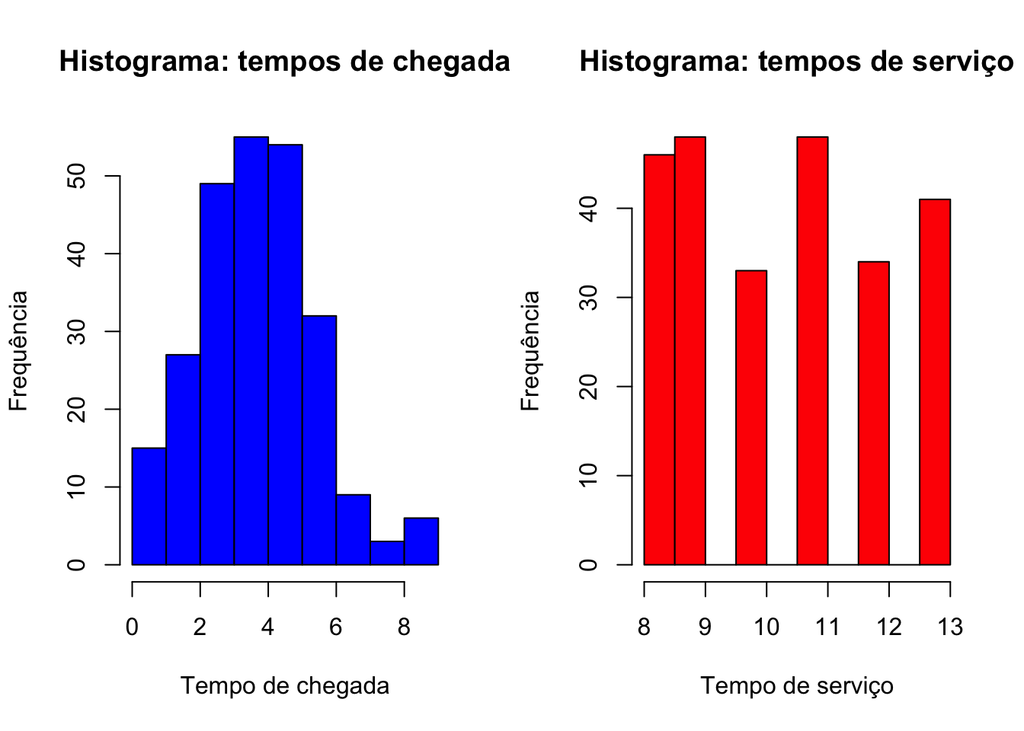

```r
df_numeros_aleatorios <- gerar_numeros_aleatorios(nrow(dataframe_tempos))

par(mfrow = c(1, 2))
hist(df_numeros_aleatorios$chegada, main = "Histograma: tempos de chegada", xlab = "Tempo de chegada", ylab = "Frequência", col = "blue")
hist(df_numeros_aleatorios$servico, main = "Histograma: tempos de serviço", xlab = "Tempo de serviço", ylab = "Frequência", col = "red")
```

### Utilizando os histogramas gerados podemos observar que os dados gerados de forma aleatória seguem o mesmo padrão dos dados originais

## Correlação

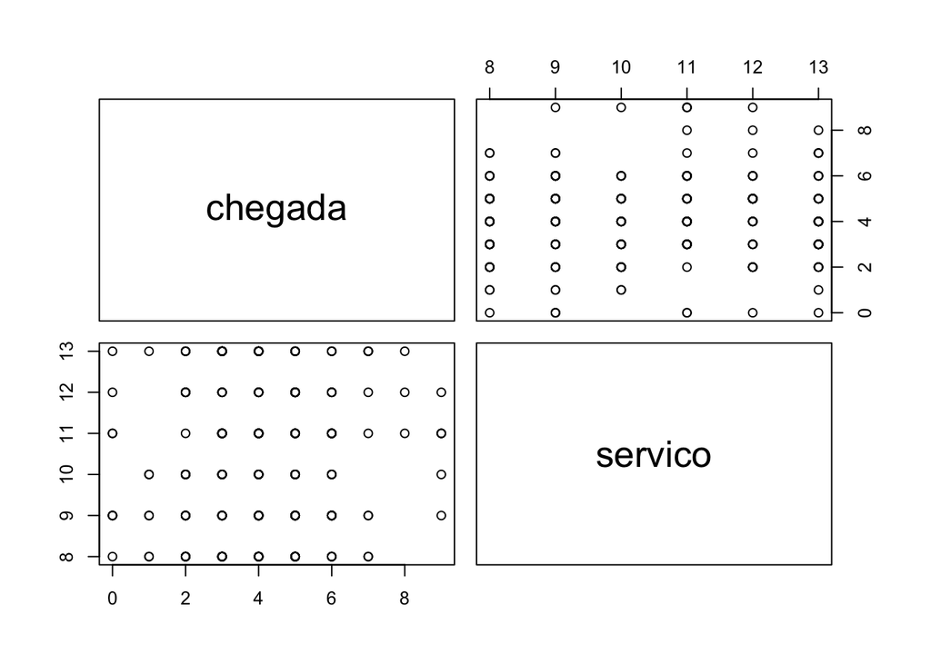

```r
pairs(df_numeros_aleatorios)
```

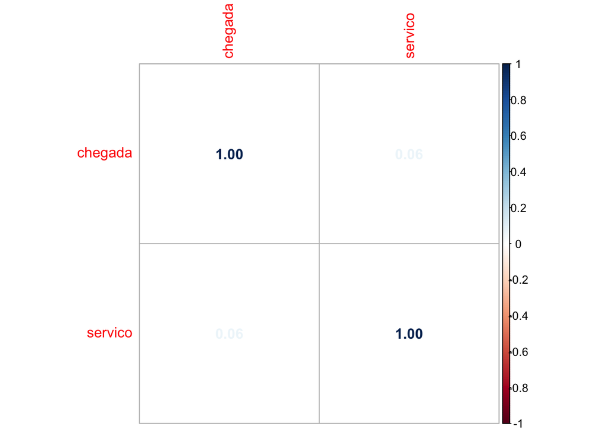

```r
corrplot(cor(df_numeros_aleatorios), method = "number")
```

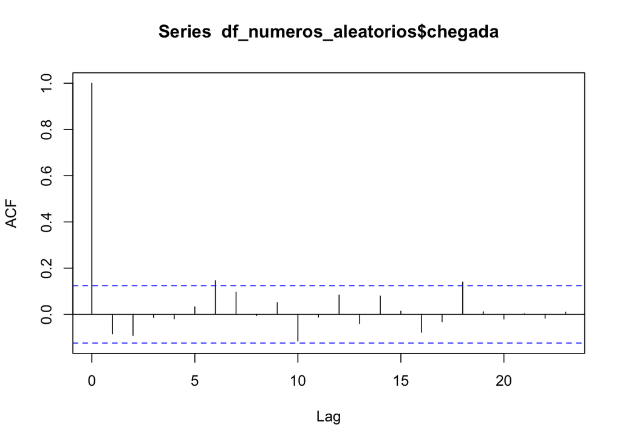

```r
acf(df_numeros_aleatorios$chegada, pl = TRUE)
```

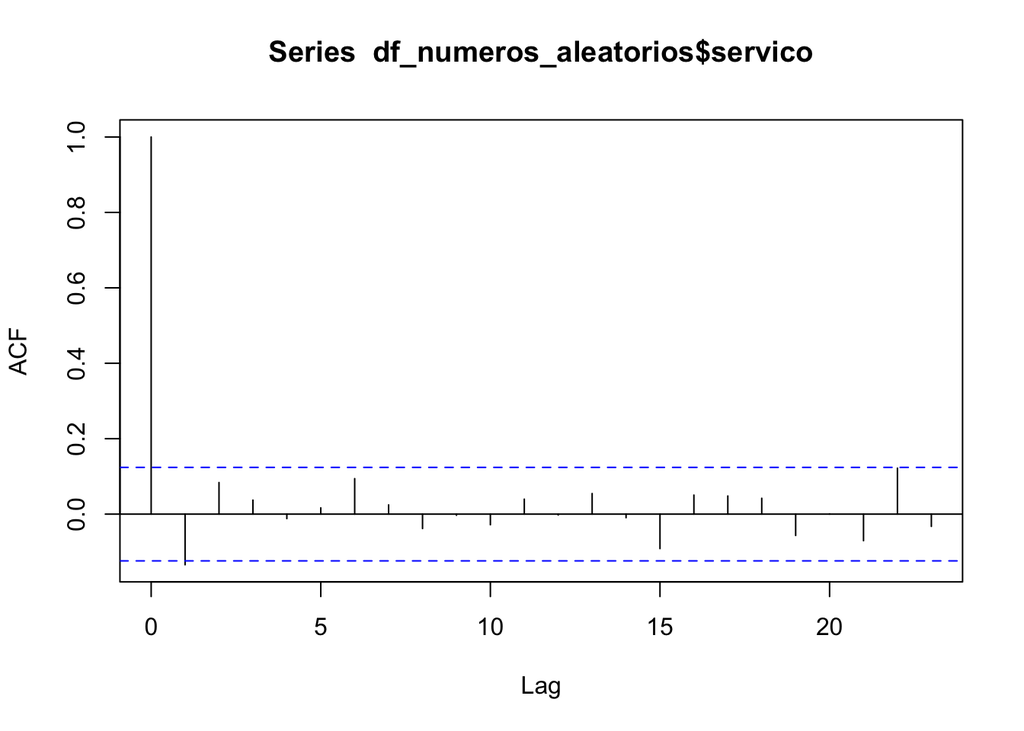

```r
acf(df_numeros_aleatorios$servico, pl = TRUE)
```

# Execução do Simulador

## Executando simulador com os dados originais

```r
df_simulado_original <- simulador_computacional(dataframe_tempos, 1)[, colunas]
rownames(df_simulado_original) <- "Original"

print(df_simulado_original)
```

```
##          valor_corte percentual_corte qtde_minimo_atendido algoritmo
## Original          NA               NA                   NA        NA
##          qtde_atendentes tempo_total tempo_total_da_fila_ocupada tempo_max_fila
## Original               1        3008                        2990           1840
##          media_na_fila tamanho_max_fila tempo_atendente_ocioso_media
## Original       926.068              154                            4
```

## Executando simulador com os dados aleatorios

```r
# Criando df com dados aleatórios e limpado-o, necessário para reutizar o método varias vezes sem
# ter problemas com resido de dados no contexto
df_simulados <- simulador_computacional(gerar_numeros_aleatorios(nrow(dataframe_tempos)), 1)
df_simulados <- df_simulados[0,]
qtde_atendentes <- 7
qtde_iteracao <- 10

for (i in 1:qtde_atendentes) {
  df_simulados <- rbind(df_simulados, simulador_computacional_iteracao(i, qtde_iteracao))
}
for (i in 1:qtde_atendentes) {
  df_simulados <- rbind(df_simulados, simulador_computacional_iteracao(i, qtde_iteracao, percentual_corte = .10, qtde_minimo_atendido = 2))
}
for (i in 1:qtde_atendentes) {
  df_simulados <- rbind(df_simulados, simulador_computacional_iteracao(i, qtde_iteracao, percentual_corte = .10, qtde_minimo_atendido = 3))
}
for (i in 1:qtde_atendentes) {
  df_simulados <- rbind(df_simulados, simulador_computacional_iteracao(i, qtde_iteracao, percentual_corte = .10, qtde_minimo_atendido = 4))
}
for (i in 1:qtde_atendentes) {
  df_simulados <- rbind(df_simulados, simulador_computacional_iteracao(i, qtde_iteracao, percentual_corte = .15, qtde_minimo_atendido = 2))
}
for (i in 1:qtde_atendentes) {
  df_simulados <- rbind(df_simulados, simulador_computacional_iteracao(i, qtde_iteracao, percentual_corte = .15, qtde_minimo_atendido = 3))
}
for (i in 1:qtde_atendentes) {
  df_simulados <- rbind(df_simulados, simulador_computacional_iteracao(i, qtde_iteracao, percentual_corte = .15, qtde_minimo_atendido = 4))
}
for (i in 1:qtde_atendentes) {
  df_simulados <- rbind(df_simulados, simulador_computacional_iteracao(i, qtde_iteracao, percentual_corte = .25, qtde_minimo_atendido = 2))
}
for (i in 1:qtde_atendentes) {
  df_simulados <- rbind(df_simulados, simulador_computacional_iteracao(i, qtde_iteracao, percentual_corte = .25, qtde_minimo_atendido = 3))
}
for (i in 1:qtde_atendentes) {
  df_simulados <- rbind(df_simulados, simulador_computacional_iteracao(i, qtde_iteracao, percentual_corte = .25, qtde_minimo_atendido = 4))
}
for (i in 1:qtde_atendentes) {
  df_simulados <- rbind(df_simulados, simulador_computacional_iteracao(i, qtde_iteracao, percentual_corte = .50, qtde_minimo_atendido = 2))
}
for (i in 1:qtde_atendentes) {
  df_simulados <- rbind(df_simulados, simulador_computacional_iteracao(i, qtde_iteracao, percentual_corte = .50, qtde_minimo_atendido = 3))
}
for (i in 1:qtde_atendentes) {
  df_simulados <- rbind(df_simulados, simulador_computacional_iteracao(i, qtde_iteracao, percentual_corte = .50, qtde_minimo_atendido = 4))
}
```

# Analisando resultados das simulações

```r
colunas2 <- c(
  "qtde_atendentes",
  "tempo_total",
  "tempo_total_da_fila_ocupada",
  "tempo_max_fila",
  "media_na_fila",
  "tamanho_max_fila",
  "tempo_atendente_ocioso_media"
)

data_grafico <- rbind(df_simulado_original, df_simulados[,colunas])[, colunas2]
```

## Correlação

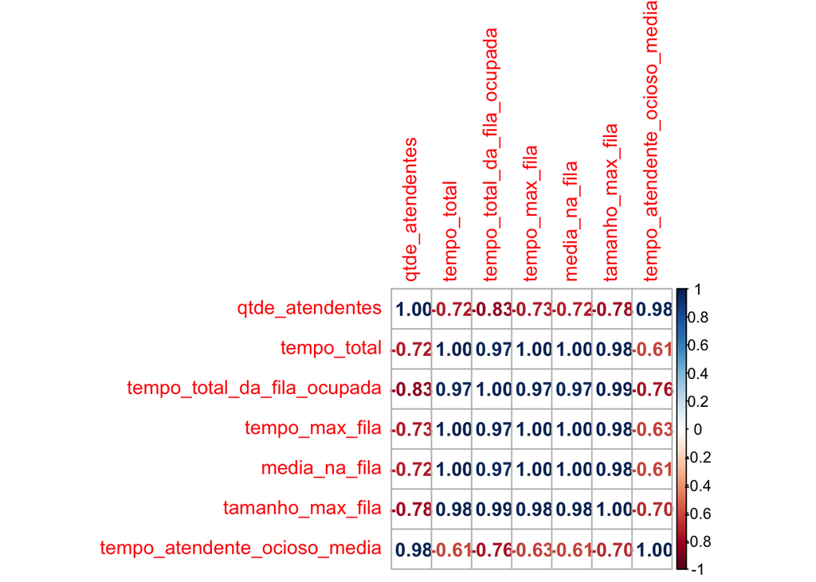

```r
# pairs(df_simulados[, c(3:11)])
corrplot(cor(data_grafico), method = "number")
```

### Podemos notar uma forte correlação entre a quantidade de atendentes e o tempo ocioso

### Também podemos ver uma forte correlação entre si nas métricas da fila, mostrando que, conforme o tamanho maximo fila diminui, o tempo médio e o tempo total da fila também diminuem.

### O tempo total do atendimento também diminui conforme o tempo da fila diminui.

## Grafico relacionando o tempo total de atendimento com o tempo de ociosidade dos atendentes

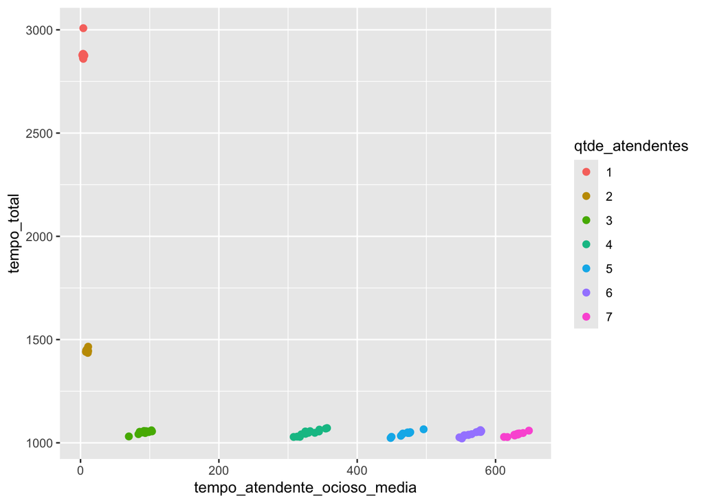

```r
data_grafico$qtde_atendentes <- as.factor(data_grafico$qtde_atendentes)

ggplot(data_grafico, aes(x=tempo_atendente_ocioso_media, y=tempo_total)) +
  geom_point(aes(col=qtde_atendentes), size=2)
```

### Com o gráfico podemos observar que as simulações com 2 atendentes possuio tempo de ociosidade próximo ao minimo e um tempo de atendimento total médio

### Já as simulações com 3 atendentes apresenta os melhores resultados, possuindo um tempo de atendimento total próximo ao minimo e um tempo ocioso baixo

### Podemos notar também que com 4 ou mais atendentes o valor total do atendimento continua próximo ao minimo porém aumentando mais o tempo de ociosidade dos atendentes

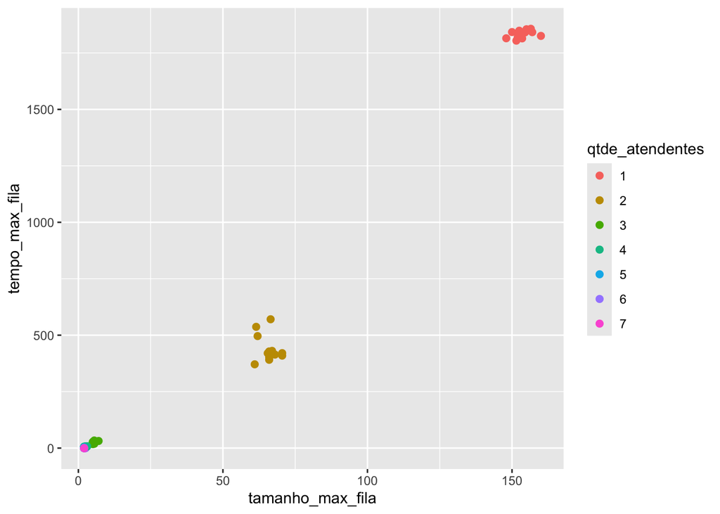

```r
ggplot(data_grafico, aes(x=tamanho_max_fila, y=tempo_max_fila)) +
  geom_point(aes(col=qtde_atendentes), size=2)
```

### Observando esse segundo grafico podemos ver que as simulações com 1 atendente possuem o tempo maximo na fila muito alto, isso cai para menos da metade com 2 atendentes.

### Já com 3 atendentes, o tempo maximo e o tamanho maximo da fila ficam próximos do minimo.

### As simulações com 4 atendentes ou novamente não apresentam ganhos significativos

## Como visto, 4 atendentes ou mais não apresentam ganhos, sendo assim iremos desconsidera-los da para frente

```r
data_grafico$qtde_atendentes <- as.integer(data_grafico$qtde_atendentes)
data_grafico <- data_grafico[data_grafico$qtde_atendentes <=3,]
```

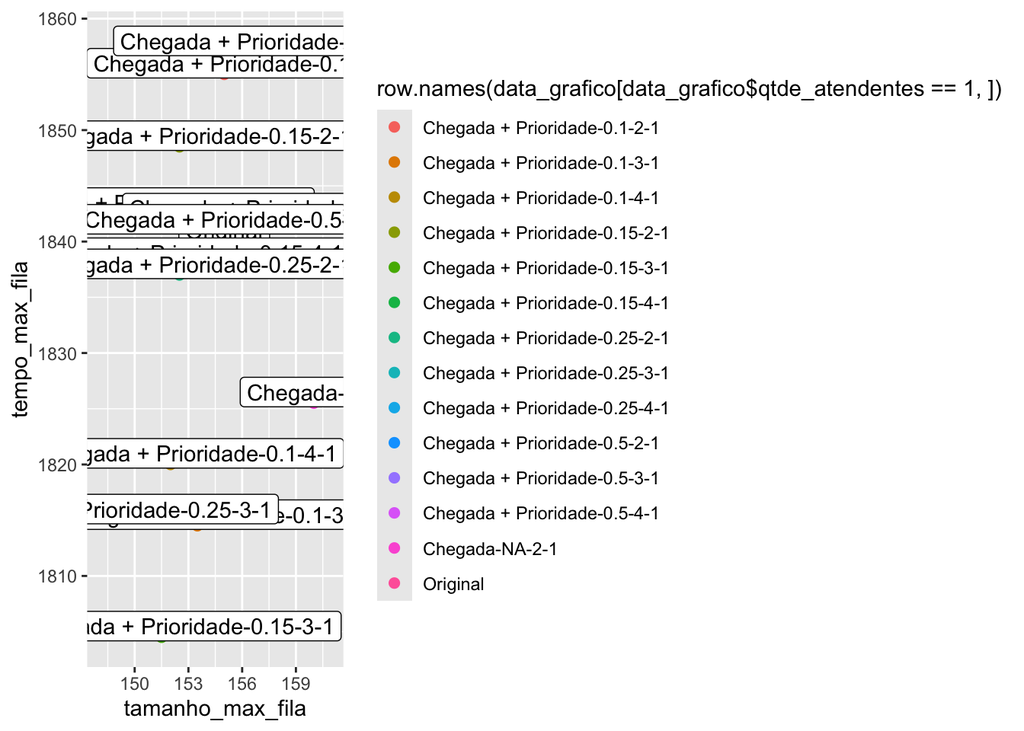

```r
ggplot(data_grafico[data_grafico$qtde_atendentes == 1,], aes(x=tamanho_max_fila, y=tempo_max_fila)) +
  geom_point(aes(col=row.names(data_grafico[data_grafico$qtde_atendentes == 1,])), size=2) +
  geom_label(
    label=rownames(data_grafico[data_grafico$qtde_atendentes == 1,]),
    nudge_x = 1, nudge_y = 1)
```

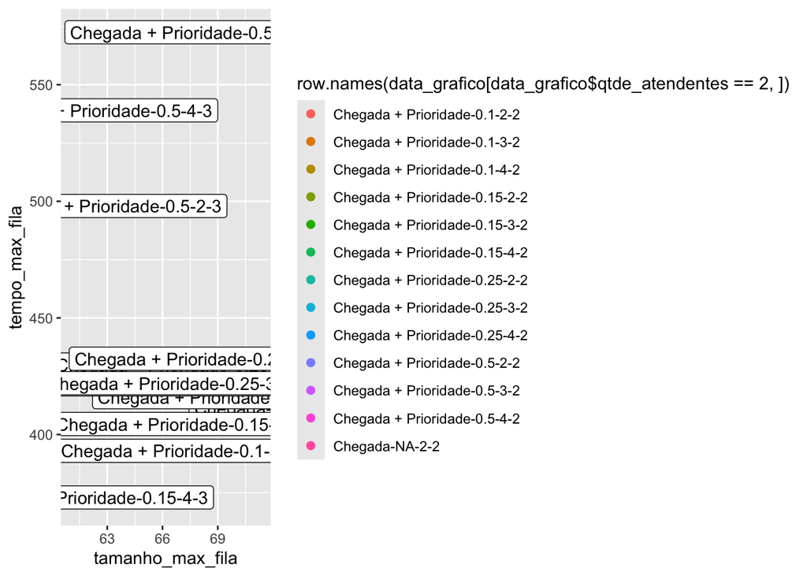

```r
ggplot(data_grafico[data_grafico$qtde_atendentes == 2,], aes(x=tamanho_max_fila, y=tempo_max_fila)) +
  geom_point(aes(col=row.names(data_grafico[data_grafico$qtde_atendentes == 2,])), size=2) +
  geom_label(
    label=rownames(data_grafico[data_grafico$qtde_atendentes == 3,]),
    nudge_x = 0.85, nudge_y = 2)
```

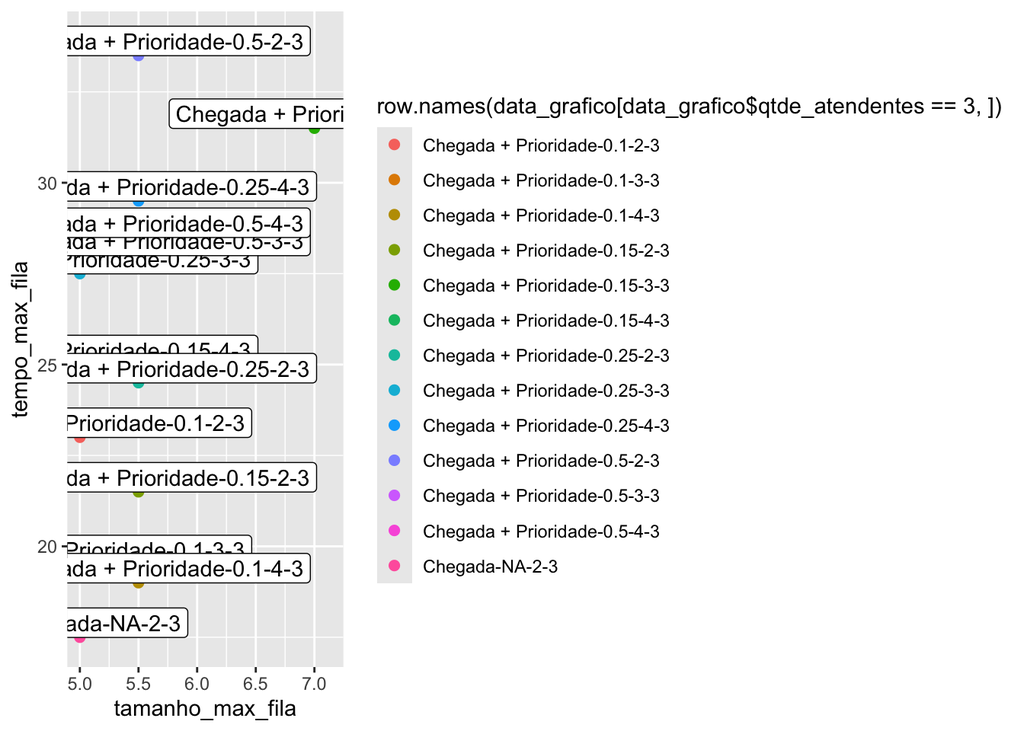

```r
ggplot(data_grafico[data_grafico$qtde_atendentes == 3,], aes(x=tamanho_max_fila, y=tempo_max_fila)) +
  geom_point(aes(col=row.names(data_grafico[data_grafico$qtde_atendentes == 3,])), size=2) +
  geom_label(
    label=rownames(data_grafico[data_grafico$qtde_atendentes == 3,]),
    nudge_x = 0.14, nudge_y = 0.4)
```

### Gerando tabela para comparação percentual dos resultados em relação ao dataset origem

```r
df_percentual_fun <- function(dados, qtde_atendentes, origem = TRUE){
  if (origem) {
    df_percentual <- rbind(dados[row.names(dados) == "Original",],dados[dados$qtde_atendentes == qtde_atendentes,])
  } else {
    df_percentual <- dados[dados$qtde_atendentes == paste("Chegada-NA-2-",as.character(qtde_atendentes)),]
    print
  }

  df_percentual$qtde_atendentes_P <- df_percentual$qtde_atendentes*100/dados[row.names(dados) == "Original",]$qtde_atendentes
  df_percentual$tempo_total_P <- df_percentual$tempo_total*100/dados[row.names(dados) == "Original",]$tempo_total
  df_percentual$tempo_total_da_fila_ocupada_P <- df_percentual$tempo_total_da_fila_ocupada*100/dados[row.names(dados) == "Original",]$tempo_total_da_fila_ocupada
  df_percentual$tempo_max_fila_P <- df_percentual$tempo_max_fila*100/dados[row.names(dados) == "Original",]$tempo_max_fila
  df_percentual$media_na_fila_P <- df_percentual$media_na_fila*100/dados[row.names(dados) == "Original",]$media_na_fila
  df_percentual$tamanho_max_fila_P <- df_percentual$tamanho_max_fila*100/dados[row.names(dados) == "Original",]$tamanho_max_fila
  df_percentual$tempo_atendente_ocioso_media_P <- df_percentual$tempo_atendente_ocioso_media*100/dados[row.names(dados) == "Original",]$tempo_atendente_ocioso_media
  df_percentual <- df_percentual[,  c(
    "qtde_atendentes",
    "qtde_atendentes_P",
    "tempo_total",
    "tempo_total_P",
    "tempo_total_da_fila_ocupada",
    "tempo_total_da_fila_ocupada_P",
    "tempo_max_fila",
    "tempo_max_fila_P",
    "media_na_fila",
    "media_na_fila_P",
    "tamanho_max_fila",
    "tamanho_max_fila_P",
    "tempo_atendente_ocioso_media",
    "tempo_atendente_ocioso_media_P"
  )]
  return(df_percentual)
}

print(df_percentual_fun(data_grafico, 1))
```

```
##                               qtde_atendentes qtde_atendentes_P tempo_total
## Original                                    1               100      3008.0
## Original1                                   1               100      3008.0
## Chegada-NA-2-1                              1               100      2875.5
## Chegada + Prioridade-0.1-2-1                1               100      2883.0
## Chegada + Prioridade-0.1-3-1                1               100      2877.5
## Chegada + Prioridade-0.1-4-1                1               100      2874.5
## Chegada + Prioridade-0.15-2-1               1               100      2869.5
## Chegada + Prioridade-0.15-3-1               1               100      2871.5
## Chegada + Prioridade-0.15-4-1               1               100      2859.5
## Chegada + Prioridade-0.25-2-1               1               100      2883.5
## Chegada + Prioridade-0.25-3-1               1               100      2863.5
## Chegada + Prioridade-0.25-4-1               1               100      2874.0
## Chegada + Prioridade-0.5-2-1                1               100      2881.5
## Chegada + Prioridade-0.5-3-1                1               100      2876.5
## Chegada + Prioridade-0.5-4-1                1               100      2881.0
##                               tempo_total_P tempo_total_da_fila_ocupada
## Original                          100.00000                      2990.0
## Original1                         100.00000                      2990.0
## Chegada-NA-2-1                     95.59508                      2857.0
## Chegada + Prioridade-0.1-2-1       95.84441                      2868.5
## Chegada + Prioridade-0.1-3-1       95.66157                      2862.5
## Chegada + Prioridade-0.1-4-1       95.56184                      2860.0
## Chegada + Prioridade-0.15-2-1      95.39561                      2851.5
## Chegada + Prioridade-0.15-3-1      95.46210                      2852.0
## Chegada + Prioridade-0.15-4-1      95.06316                      2841.0
## Chegada + Prioridade-0.25-2-1      95.86104                      2862.5
## Chegada + Prioridade-0.25-3-1      95.19614                      2847.0
## Chegada + Prioridade-0.25-4-1      95.54521                      2856.0
## Chegada + Prioridade-0.5-2-1       95.79455                      2863.0
## Chegada + Prioridade-0.5-3-1       95.62832                      2857.5
## Chegada + Prioridade-0.5-4-1       95.77793                      2856.5
##                               tempo_total_da_fila_ocupada_P tempo_max_fila
## Original                                          100.00000         1840.0
## Original1                                         100.00000         1840.0
## Chegada-NA-2-1                                     95.55184         1825.5
## Chegada + Prioridade-0.1-2-1                       95.93645         1855.0
## Chegada + Prioridade-0.1-3-1                       95.73579         1814.5
## Chegada + Prioridade-0.1-4-1                       95.65217         1820.0
## Chegada + Prioridade-0.15-2-1                      95.36789         1848.5
```

[output cut: 57 more lines]

```
## Original                                               100.0
## Original1                                              100.0
## Chegada-NA-2-1                                         137.5
## Chegada + Prioridade-0.1-2-1                           100.0
## Chegada + Prioridade-0.1-3-1                            62.5
## Chegada + Prioridade-0.1-4-1                           112.5
## Chegada + Prioridade-0.15-2-1                          100.0
## Chegada + Prioridade-0.15-3-1                          100.0
## Chegada + Prioridade-0.15-4-1                          100.0
## Chegada + Prioridade-0.25-2-1                           87.5
## Chegada + Prioridade-0.25-3-1                           87.5
## Chegada + Prioridade-0.25-4-1                          112.5
## Chegada + Prioridade-0.5-2-1                           100.0
## Chegada + Prioridade-0.5-3-1                           125.0
## Chegada + Prioridade-0.5-4-1                           112.5
```

```r
print(df_percentual_fun(data_grafico, 2))
```

```
##                               qtde_atendentes qtde_atendentes_P tempo_total
## Original                                    1               100      3008.0
## Chegada-NA-2-2                              2               200      1451.0
## Chegada + Prioridade-0.1-2-2                2               200      1441.5
## Chegada + Prioridade-0.1-3-2                2               200      1446.0
## Chegada + Prioridade-0.1-4-2                2               200      1446.5
## Chegada + Prioridade-0.15-2-2               2               200      1451.0
## Chegada + Prioridade-0.15-3-2               2               200      1445.5
## Chegada + Prioridade-0.15-4-2               2               200      1443.0
## Chegada + Prioridade-0.25-2-2               2               200      1440.5
## Chegada + Prioridade-0.25-3-2               2               200      1444.5
## Chegada + Prioridade-0.25-4-2               2               200      1465.5
## Chegada + Prioridade-0.5-2-2                2               200      1435.5
## Chegada + Prioridade-0.5-3-2                2               200      1454.0
## Chegada + Prioridade-0.5-4-2                2               200      1442.5
##                               tempo_total_P tempo_total_da_fila_ocupada
## Original                          100.00000                      2990.0
## Chegada-NA-2-2                     48.23803                      1425.0
## Chegada + Prioridade-0.1-2-2       47.92221                      1417.5
## Chegada + Prioridade-0.1-3-2       48.07181                      1420.5
## Chegada + Prioridade-0.1-4-2       48.08843                      1423.5
## Chegada + Prioridade-0.15-2-2      48.23803                      1428.0
## Chegada + Prioridade-0.15-3-2      48.05519                      1421.5
## Chegada + Prioridade-0.15-4-2      47.97207                      1415.0
## Chegada + Prioridade-0.25-2-2      47.88896                      1420.0
## Chegada + Prioridade-0.25-3-2      48.02194                      1418.5
## Chegada + Prioridade-0.25-4-2      48.72008                      1444.5
## Chegada + Prioridade-0.5-2-2       47.72274                      1408.5
## Chegada + Prioridade-0.5-3-2       48.33777                      1429.0
## Chegada + Prioridade-0.5-4-2       47.95545                      1418.5
##                               tempo_total_da_fila_ocupada_P tempo_max_fila
## Original                                          100.00000         1840.0
## Chegada-NA-2-2                                     47.65886          409.5
## Chegada + Prioridade-0.1-2-2                       47.40803          414.0
## Chegada + Prioridade-0.1-3-2                       47.50836          391.0
## Chegada + Prioridade-0.1-4-2                       47.60870          420.5
## Chegada + Prioridade-0.15-2-2                      47.75920          402.5
## Chegada + Prioridade-0.15-3-2                      47.54181          419.5
## Chegada + Prioridade-0.15-4-2                      47.32441          371.0
## Chegada + Prioridade-0.25-2-2                      47.49164          428.0
```

[output cut: 50 more lines]

```
##                               tempo_atendente_ocioso_media_P
## Original                                              100.00
## Chegada-NA-2-2                                        218.75
## Chegada + Prioridade-0.1-2-2                          231.25
## Chegada + Prioridade-0.1-3-2                          225.00
## Chegada + Prioridade-0.1-4-2                          200.00
## Chegada + Prioridade-0.15-2-2                         231.25
## Chegada + Prioridade-0.15-3-2                         206.25
## Chegada + Prioridade-0.15-4-2                         212.50
## Chegada + Prioridade-0.25-2-2                         193.75
## Chegada + Prioridade-0.25-3-2                         275.00
## Chegada + Prioridade-0.25-4-2                         275.00
## Chegada + Prioridade-0.5-2-2                          262.50
## Chegada + Prioridade-0.5-3-2                          243.75
## Chegada + Prioridade-0.5-4-2                          256.25
```

```r
print(df_percentual_fun(data_grafico, 3))
```

```
##                               qtde_atendentes qtde_atendentes_P tempo_total
## Original                                    1               100      3008.0
## Chegada-NA-2-3                              3               300      1047.5
## Chegada + Prioridade-0.1-2-3                3               300      1050.5
## Chegada + Prioridade-0.1-3-3                3               300      1055.5
## Chegada + Prioridade-0.1-4-3                3               300      1052.0
## Chegada + Prioridade-0.15-2-3               3               300      1056.5
## Chegada + Prioridade-0.15-3-3               3               300      1031.0
## Chegada + Prioridade-0.15-4-3               3               300      1042.0
## Chegada + Prioridade-0.25-2-3               3               300      1051.0
## Chegada + Prioridade-0.25-3-3               3               300      1060.5
## Chegada + Prioridade-0.25-4-3               3               300      1051.5
## Chegada + Prioridade-0.5-2-3                3               300      1057.5
## Chegada + Prioridade-0.5-3-3                3               300      1053.5
## Chegada + Prioridade-0.5-4-3                3               300      1055.0
##                               tempo_total_P tempo_total_da_fila_ocupada
## Original                          100.00000                      2990.0
## Chegada-NA-2-3                     34.82380                       641.5
## Chegada + Prioridade-0.1-2-3       34.92354                       630.5
## Chegada + Prioridade-0.1-3-3       35.08976                       586.0
## Chegada + Prioridade-0.1-4-3       34.97340                       628.0
## Chegada + Prioridade-0.15-2-3      35.12301                       651.5
## Chegada + Prioridade-0.15-3-3      34.27527                       722.0
## Chegada + Prioridade-0.15-4-3      34.64096                       675.5
## Chegada + Prioridade-0.25-2-3      34.94016                       640.0
## Chegada + Prioridade-0.25-3-3      35.25598                       625.5
## Chegada + Prioridade-0.25-4-3      34.95678                       602.5
## Chegada + Prioridade-0.5-2-3       35.15625                       647.0
## Chegada + Prioridade-0.5-3-3       35.02327                       684.0
## Chegada + Prioridade-0.5-4-3       35.07314                       634.5
##                               tempo_total_da_fila_ocupada_P tempo_max_fila
## Original                                          100.00000         1840.0
## Chegada-NA-2-3                                     21.45485           17.5
## Chegada + Prioridade-0.1-2-3                       21.08696           23.0
## Chegada + Prioridade-0.1-3-3                       19.59866           19.5
## Chegada + Prioridade-0.1-4-3                       21.00334           19.0
## Chegada + Prioridade-0.15-2-3                      21.78930           21.5
## Chegada + Prioridade-0.15-3-3                      24.14716           31.5
## Chegada + Prioridade-0.15-4-3                      22.59197           25.0
## Chegada + Prioridade-0.25-2-3                      21.40468           24.5
```

[output cut: 50 more lines]

```
##                               tempo_atendente_ocioso_media_P
## Original                                             100.000
## Chegada-NA-2-3                                      2337.500
## Chegada + Prioridade-0.1-2-3                        2258.333
## Chegada + Prioridade-0.1-3-3                        2583.333
## Chegada + Prioridade-0.1-4-3                        2466.667
## Chegada + Prioridade-0.15-2-3                       2370.833
## Chegada + Prioridade-0.15-3-3                       1745.833
## Chegada + Prioridade-0.15-4-3                       2091.667
## Chegada + Prioridade-0.25-2-3                       2200.000
## Chegada + Prioridade-0.25-3-3                       2562.500
## Chegada + Prioridade-0.25-4-3                       2370.833
## Chegada + Prioridade-0.5-2-3                        2291.667
## Chegada + Prioridade-0.5-3-3                        2137.500
## Chegada + Prioridade-0.5-4-3                        2433.333
```

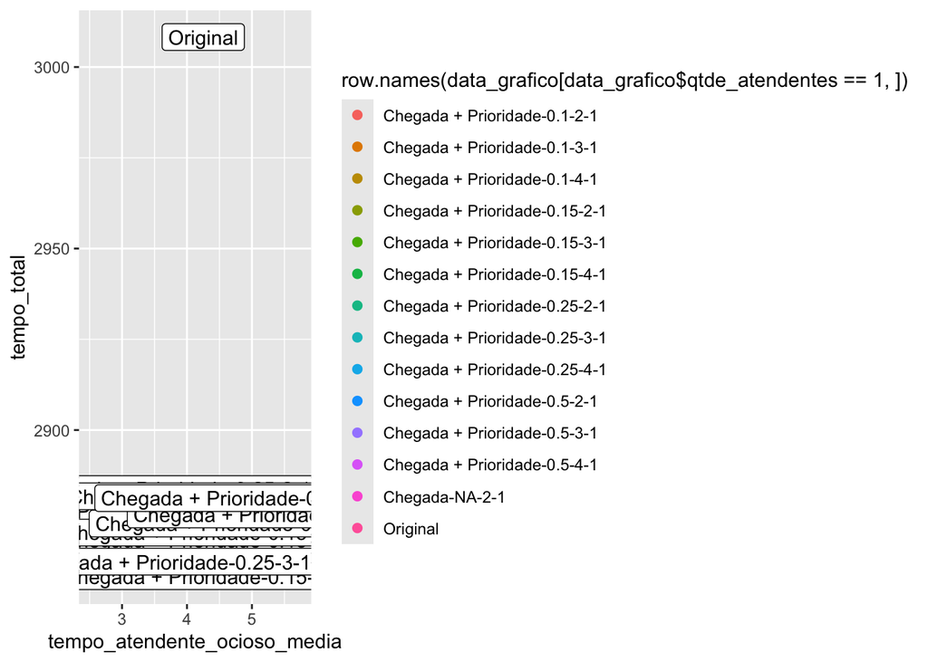

```r
ggplot(data_grafico[data_grafico$qtde_atendentes == 1,], aes(x=tempo_atendente_ocioso_media, y=tempo_total)) +
  geom_point(aes(col=row.names(data_grafico[data_grafico$qtde_atendentes == 1,])), size=2) +
  geom_label(
    label=rownames(data_grafico[data_grafico$qtde_atendentes == 1,]),
    nudge_x = 0.25, nudge_y = 0.25)
```

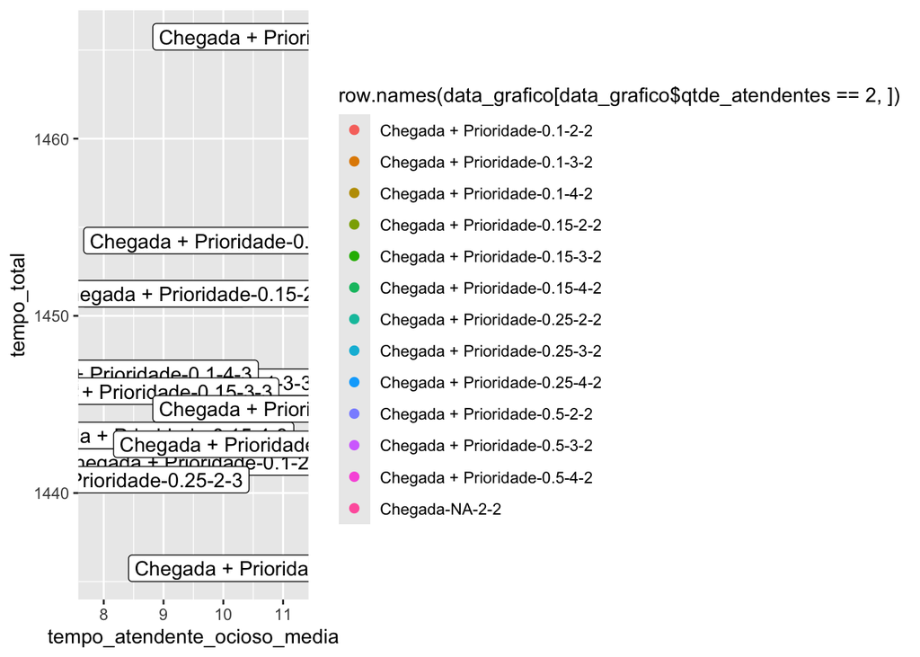

```r
ggplot(data_grafico[data_grafico$qtde_atendentes == 2,], aes(x=tempo_atendente_ocioso_media, y=tempo_total)) +
  geom_point(aes(col=row.names(data_grafico[data_grafico$qtde_atendentes == 2,])), size=2) +
  geom_label(
    label=rownames(data_grafico[data_grafico$qtde_atendentes == 3,]),
    nudge_x = 0.25, nudge_y = 0.25
  )
```

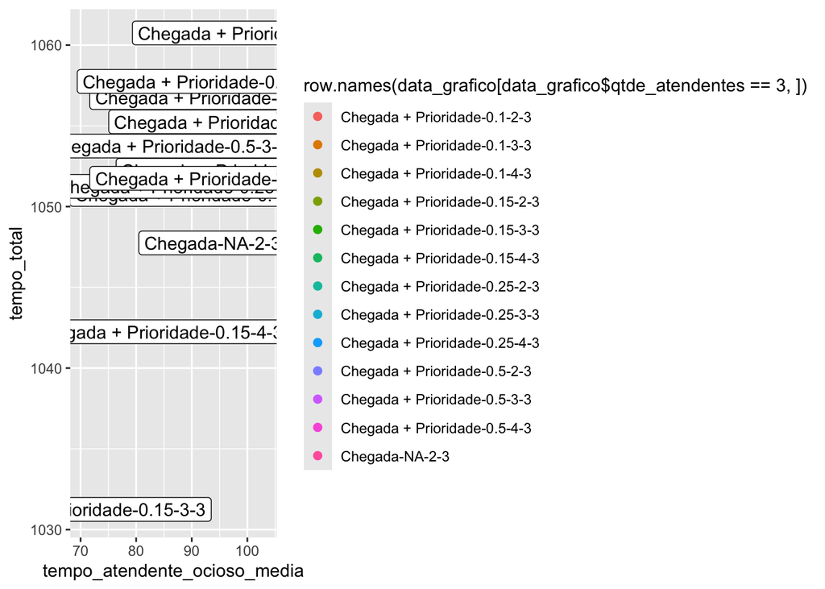

```r
ggplot(data_grafico[data_grafico$qtde_atendentes == 3,], aes(x=tempo_atendente_ocioso_media, y=tempo_total)) +
  geom_point(aes(col=row.names(data_grafico[data_grafico$qtde_atendentes == 3,])), size=2) +
  geom_label(
    label=rownames(data_grafico[data_grafico$qtde_atendentes == 3,]),
    nudge_x = 0.25, nudge_y = 0.25)
```

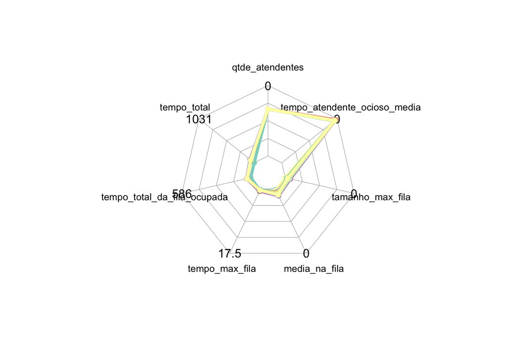

```r
# Grafico de rede das simulações de 1 atendente

valores_minimos <- c(0, min(data_grafico$tempo_total), min(data_grafico$tempo_total_da_fila_ocupada), min(data_grafico$tempo_max_fila), 0, 0, 0)
valores_maximos <- c(3, max(data_grafico$tempo_total), max(data_grafico$tempo_total_da_fila_ocupada), max(data_grafico$tempo_max_fila), max(data_grafico$media_na_fila), max(data_grafico$tamanho_max_fila), max(data_grafico$tempo_atendente_ocioso_media))
data_grafico_spider_1 <- rbind(
  valores_minimos,
  valores_maximos,
  data_grafico[data_grafico$qtde_atendentes == 1,])

library(RColorBrewer)
coul <- brewer.pal(12, "Set3")
colors_border <- coul
library(scales)
colors_in <- alpha(coul,0)

# plot with default options:
radarchart( data_grafico_spider_1  , axistype=2 ,
            #custom polygon
            pcol=colors_border , pfcol=colors_in , plwd=4 , plty=1,
            #custom the grid
            cglcol="grey", cglty=1, axislabcol="black", cglwd=0.8,
            #custom labels
            vlcex=0.8
)
```

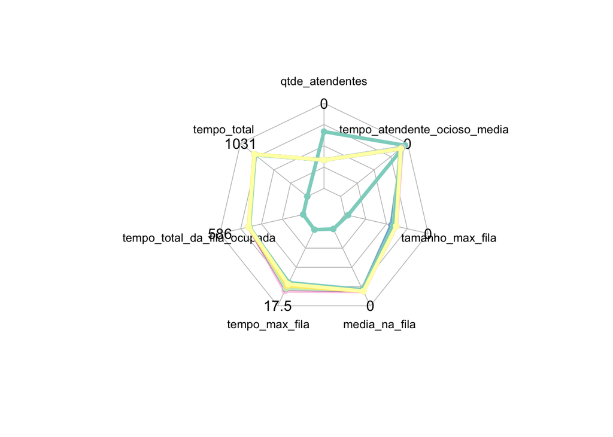

```r
# Add a legend
# legend(x=1.3, y=1, legend = rownames(data_grafico_spider_1[-c(1,2),]), bty = "n", pch=20 , col=colors_border , text.col = "grey", cex=1.2, pt.cex=3)

# Grafico de rede das simulações de 2 atendente
data_grafico_spider_2 <- rbind(
  valores_minimos,
  valores_maximos,
  data_grafico[row.names(data_grafico) == "Original",],
  data_grafico[data_grafico$qtde_atendentes == 2,])

# plot with default options:
radarchart( data_grafico_spider_2  , axistype=2 ,
            #custom polygon
            pcol=colors_border , pfcol=colors_in , plwd=4 , plty=1,
            #custom the grid
            cglcol="grey", cglty=1, axislabcol="black", cglwd=0.8,
            #custom labels
            vlcex=0.8
)
```

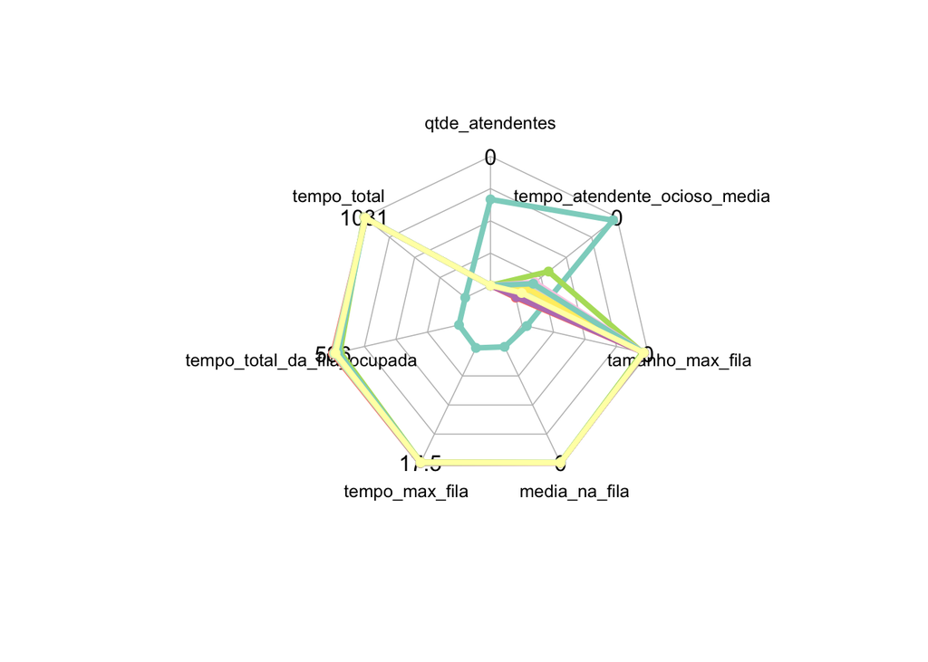

```r
# Add a legend
# legend(x=1.3, y=1, legend = rownames(data_grafico_spider_2[-c(1,2),]), bty = "n", pch=20 , col=colors_border , text.col = "grey", cex=1.2, pt.cex=3)


# Grafico de rede das simulações de 3 atendente
data_grafico_spider_3 <- rbind(
  valores_minimos,
  valores_maximos,
  data_grafico[row.names(data_grafico) == "Original",],
  data_grafico[data_grafico$qtde_atendentes == 3,])

# plot with default options:
radarchart( data_grafico_spider_3, axistype=2 ,
            #custom polygon
            pcol=colors_border , pfcol=colors_in , plwd=4 , plty=1,
            #custom the grid
            cglcol="grey", cglty=1, axislabcol="black", cglwd=0.8,
            #custom labels
            vlcex=0.8
)
```

```r
# legend(x=1.3, y=1, legend = rownames(data_grafico_spider_3[-c(1,2),]), bty = "n", pch=20 , col=colors_border , text.col = "grey", cex=1.2, pt.cex=3)
```